# Análisis de temperaturas de Argentina

Visualización de datos - Taller de Comunicación Estadística

Guillermo Solovey

6 de Sep 2022

## Descripción del ejercicio

Este es un ejercicio de visualización de datos con un dataset de temperaturas diarias registradas en Argentina durante los últimos 365 días. Descargué el dataset de la página de datos públicos https://datos.gob.ar (más precisamente, en [este link](https://datos.gob.ar/dataset/smn-registro-temperatura-365-dias/archivo/smn_5.1)) el 5 de Septiembre de 2022. El archivo descargado (`Registro_temperaturas-05092022.zip`) contiene el dataset `registro_temperatura365d_smn.txt` que ahora está en la carpeta `datos` de este proyecto.

El dataset incluye la temperatura mínima y la máxima de los últimos 365 días de distintas estaciones meteorológicas de Argentina. En la primera parte de este ejercicio, muestro tres formas diferentes de graficar las temperaturas de CABA agrupadas por mes. En la segunda parte, analizo las temperaturas de CABA y Mendoza. En principio, la correlación entre ambas. Luego, dado que Mendoza está más lejos del mar y a más altura, me pregunto si la amplitud térmica allí es mayor que en CABA.

## Importo los datos

Importo los datos, me quedo sólo con las tempearaturas registradas en Aeroparque (CABA) y agrego al dataset las variables temperatura promedio de cada día, el mes y el año.

```r
require(tidyverse)
require(lubridate)

d <- read_table2("datos/registro_temperatura365d_smn.txt",
                 col_types = cols(FECHA = col_datetime(format = "%d%m%Y"),
                                  TMAX = col_number(),
                                  TMIN = col_number()))


d.CABA <- d %>%
  filter(NOMBRE == "AEROPARQUE") %>%
  select(1:3) %>%
  mutate(TMEAN = (TMIN+TMAX)/2,
         MES = month(as.POSIXlt(FECHA, format="%d%m%Y")),
         ANO = year(as.POSIXlt(FECHA, format="%d%m%Y")))


# lo que sigue es medio chancho pero sirve poner en orden los meses (lo que
# queda de septiembre, octubre, noviembre y diciembre) en los gráficos que
# siguen. si se les ocurre una forma mejor, me avisan.

d.CABA$MES[d.CABA$MES==12] <- 0
d.CABA$MES[d.CABA$MES==11] <- -1
d.CABA$MES[d.CABA$MES==10] <- -2
d.CABA$MES[d.CABA$MES==9 & d.CABA$ANO==2021] <- -3

d.CABA$MES <- as.factor(d.CABA$MES)

d
```

| FECHA | TMAX | TMIN | NOMBRE | X5 |
| --- | --- | --- | --- | --- |
|  | NA | NA | ---------------------------------------- | NA |
| 2022-09-04 | 19.7 | 9.4 | AEROPARQUE | AERO |
| 2022-09-04 | 22.5 | 3.7 | AZUL | AERO |
| 2022-09-04 | 21.5 | 9.4 | BAHIA | BLANCA |
| 2022-09-04 | 19.4 | -2.0 | BARILOCHE | AERO |
| 2022-09-04 | -12.5 | -20.5 | BASE | BELGRANO |
| 2022-09-04 | 0.1 | -4.2 | BASE | CARLINI |
| 2022-09-04 | -5.5 | -15.3 | BASE | ESPERANZA |
| 2022-09-04 | -15.0 | -22.8 | BASE | MARAMBIO |
| 2022-09-04 | -1.2 | -10.4 | BASE | ORCADAS |

[output cut: 9990 more lines]

## Ejemplo con el paquete ggbeeswarm

El paquete **ggbeeswarm** permite hacer gráficos de violin con scatter plots:

> Beeswarm plots (aka column scatter plots or violin scatter plots) are a way of plotting points that would ordinarily overlap so that they fall next to each other instead. In addition to reducing overplotting, it helps visualize the density of the data at each point (similar to a violin plot), while still showing each data point individually.

> ggbeeswarm

Más fácil verlo con un ejemplo…

### Código

```r
require(ggbeeswarm)
l.meses <- c("sep 21", "oct 21", "nov 21", "dic 21", "ene 22", "feb 22","mar 22",
             "abr 22","may 22", "jun 22","jul 22", "ago 22","sep 22")

g1 <- ggplot(data = d.CABA, mapping = aes(x = MES, y = TMEAN, color = TMEAN)) +
  geom_quasirandom(size = 1) +
  scale_color_viridis_c(option = "plasma") +
  guides(color = "none") +
  labs(title = "Temperatura promedio en CABA",
       subtitle = "datos de los últimos 365 días",
       caption = "fecha: 5 Sep 2022") +
  scale_x_discrete(name="",
                   breaks=-3:9,
                   labels=l.meses) +
  scale_y_continuous(name="Temperatura (°C)",
                     limits = c(5,35)) +
  theme_minimal() +
  coord_flip() +
  theme(legend.position = "none",
        panel.grid.major.x = element_blank(),
        panel.grid.minor.x = element_blank(),
        panel.border = element_blank(),
        panel.background = element_blank())
```

### Output

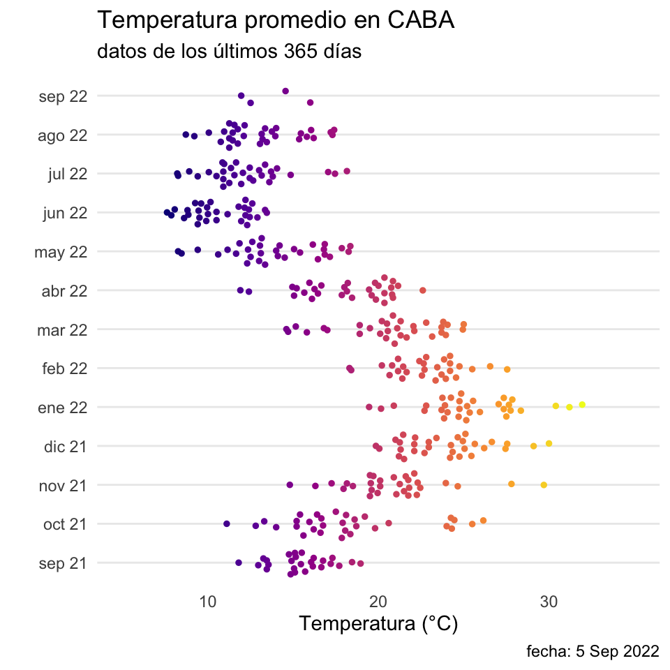

## Ejemplo con el paquete raincloudplots

Con el paquete **raincloudplots** se pueden crear lindas visualizaciones de distribuciones que combinan un boxplot, un gráfico de la densidad y un scatter plot.

### Código

```r
require(cowplot)
source('scripts/R_rainclouds.R')

g2 <- ggplot(data = d.CABA, mapping = aes(x = MES, y = TMEAN, fill = MES)) +
  geom_flat_violin(position = position_nudge(x = .2, y = 0),
                   adjust = .8) +
  geom_point(position = position_jitter(width = .05),
             size = .25) +
  geom_boxplot(aes(x = as.numeric(MES)+0.25, y = TMEAN),
               position = position_nudge(x = -.12, y = 0),
               outlier.shape = NA,
               alpha = 0.3,
               width = .1,
               colour = "BLACK") +
  labs(title = "Temperatura promedio en CABA",
       subtitle = "datos de los últimos 365 días",
       caption = "fecha: 5 Sep 2022") +
  scale_x_discrete(name="",
                   breaks=-3:9,
                   labels=l.meses) +
  scale_y_continuous(name="Temperatura (°C)",
                     limits = c(5,35)) +
  theme_cowplot() +
  coord_flip() +
  theme(legend.position = "none",
        panel.grid.major.x = element_blank(),
        panel.grid.minor.x = element_blank(),
        panel.border = element_blank(),
        plot.title = element_text(face="plain"),
        panel.background = element_blank())
```

### Output

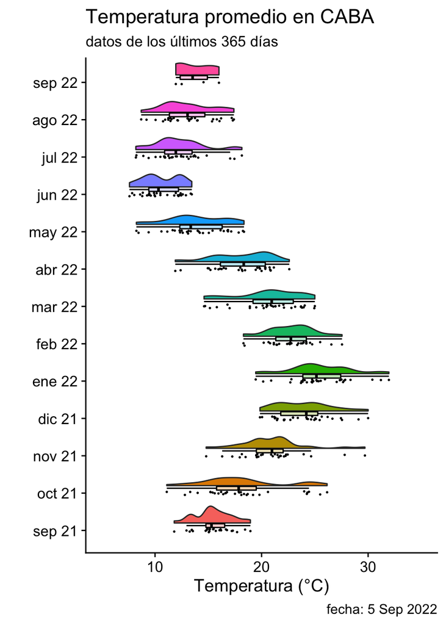

## Ejemplo con el paquete ggridges

**ggridges** es un paquete que puede servir para mostrar cambios en las distribuciones. Por ejemplo, a lo largo del tiempo o en distintos lugares.

### Código

```r
require(ggridges)
#require(forcats)

d2 <- d.CABA %>%
  pivot_longer(cols = 2:3, values_to = "T", names_to = "TIPO")

g3 <- ggplot(d2, aes(x = T, y = as_factor(MES), fill = TIPO)) +
  geom_density_ridges(alpha = 0.5) +
  scale_fill_discrete(name = "",
                      labels=c('Temp min.', 'Temp max.')) +
  labs(x = "Temperatura (°C)",
       y = NULL,
       color = "Temp") +
  scale_y_discrete(name="",
                   breaks=-3:9,
                   labels=l.meses) +
  labs(title = "Temperatura mínima y máxima en CABA",
       subtitle = "datos de los últimos 365 días",
       caption = "fecha: 5 Sep 2022") +
  theme_minimal() +
  theme(panel.grid.major.x = element_blank(),
        panel.grid.minor.x = element_blank(),
        panel.border = element_blank(),
        panel.background = element_blank())
```

### Output

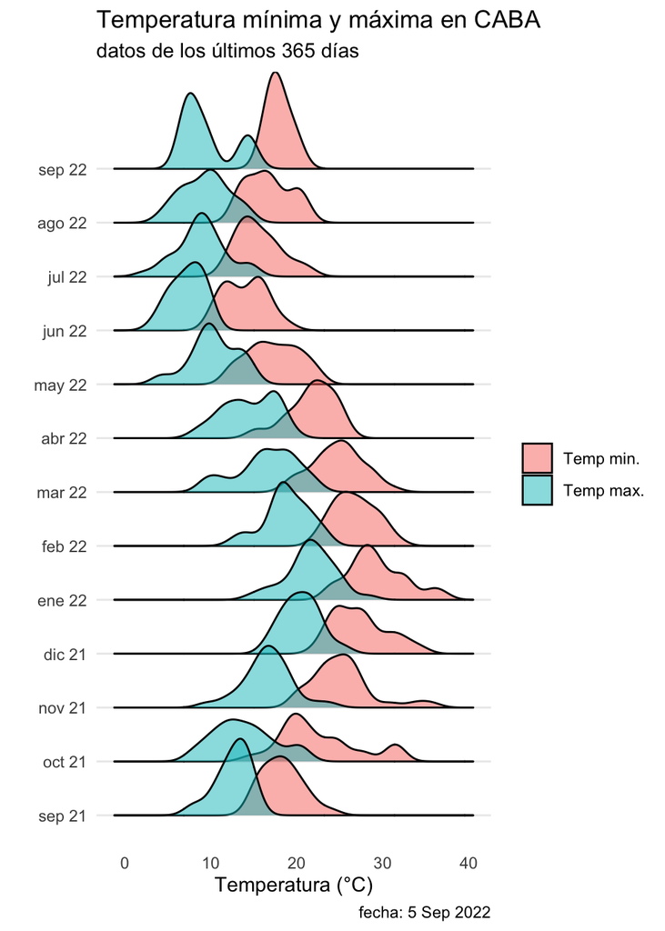

## Amplitud térmica en CABA vs Mendoza

### Código

```r
d2 <- d %>%
  filter(NOMBRE == "AEROPARQUE" | (NOMBRE == "MENDOZA" & X5 =="AERO") ) %>%
  select(1:4) %>%
  mutate(TMEAN = (TMIN+TMAX)/2,
         AT = TMAX - TMIN,
         MES = month(as.POSIXlt(FECHA, format="%d%m%Y")),
         ANO = year(as.POSIXlt(FECHA, format="%d%m%Y")))

g4 <- ggplot(data = d2, mapping = aes(x = NOMBRE, y = AT, fill = NOMBRE)) +
  geom_flat_violin(position = position_nudge(x = 0.1, y = 0), adjust = 2) +
  geom_point(position = position_jitter(width = .05), size = .25) +
  geom_boxplot(aes(x = NOMBRE, y = AT),
               outlier.shape = NA,
               alpha = 0.3,
               width = .1,
               colour = "BLACK") +
  labs(title = "CABA vs. Mendoza",
       subtitle = "amplitud térmica de los últimos 365",
       caption = "fecha: 5 Sep 2022") +
  scale_x_discrete(name="",
                   labels=c("CABA", "Mendoza")) +
  scale_y_continuous(name="Amplitud Térmica (°C)",
                     limits = c(0,27)) +
  theme_cowplot() +
  coord_flip() +
  theme(legend.position = "none",
        panel.grid.major.x = element_blank(),
        panel.grid.minor.x = element_blank(),
        panel.border = element_blank(),
        plot.title = element_text(face="plain"),
        panel.background = element_blank())
```

### Output

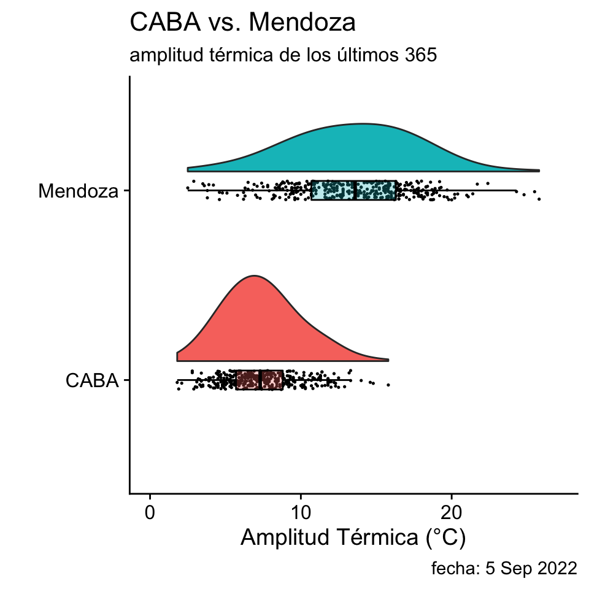

## Correlación de la temperatura CABA - Mendoza

Como último ejemplo, y para mostrar otro tipo de gráfico que podemos hacer, voy a estudiar la asociación entre la temperatura media en CABA y Mendoza. Obviamente esperamos encontrar una correlación positiva.

### Código

```r
d2 <- d %>%
  filter(NOMBRE == "AEROPARQUE" | (NOMBRE == "MENDOZA" & X5 =="AERO") ) %>%
  select(1:4) %>%
  mutate(TMEAN = (TMIN+TMAX)/2,
         AT = TMAX - TMIN,
         MES = month(as.POSIXlt(FECHA, format="%d%m%Y")),
         ANO = year(as.POSIXlt(FECHA, format="%d%m%Y")))


d2 <- d2 %>%
  select(c(1,4,5)) %>%
  pivot_wider(names_from = NOMBRE, values_from = TMEAN) %>%
  mutate(MES = month(as.POSIXlt(FECHA, format="%d%m%Y")))

# voy a hacer un scatter plot pero el color de cada punto quiero que sea
# diferente de acuerdo al mes. creo estos labels.
l.meses <- c("ene", "feb","mar",
             "abr","may", "jun",
             "jul", "ago","sep",
             "oct", "nov","dec")

g5 <- ggplot(data = d2, mapping = aes(x = AEROPARQUE, y = MENDOZA)) +
  geom_smooth(method = "lm", se = F) +
  geom_point(aes(color = factor(MES))) +
  labs(title = "Correlación de temperaturas en CABA - Mendoza",
       subtitle = "temperatura media de los últimos 365") +
  scale_y_continuous(name="Temperatura media en MDZ (°C)",
                     limits = c(0,30)) +
  scale_x_continuous(name="Temperatura media en CABA (°C)",
                     limits = c(0,30)) +
  scale_color_discrete(name = "",
                       labels=l.meses) +
  theme_minimal() +
  theme(panel.border = element_blank(),
        panel.background = element_blank())
```

### Output

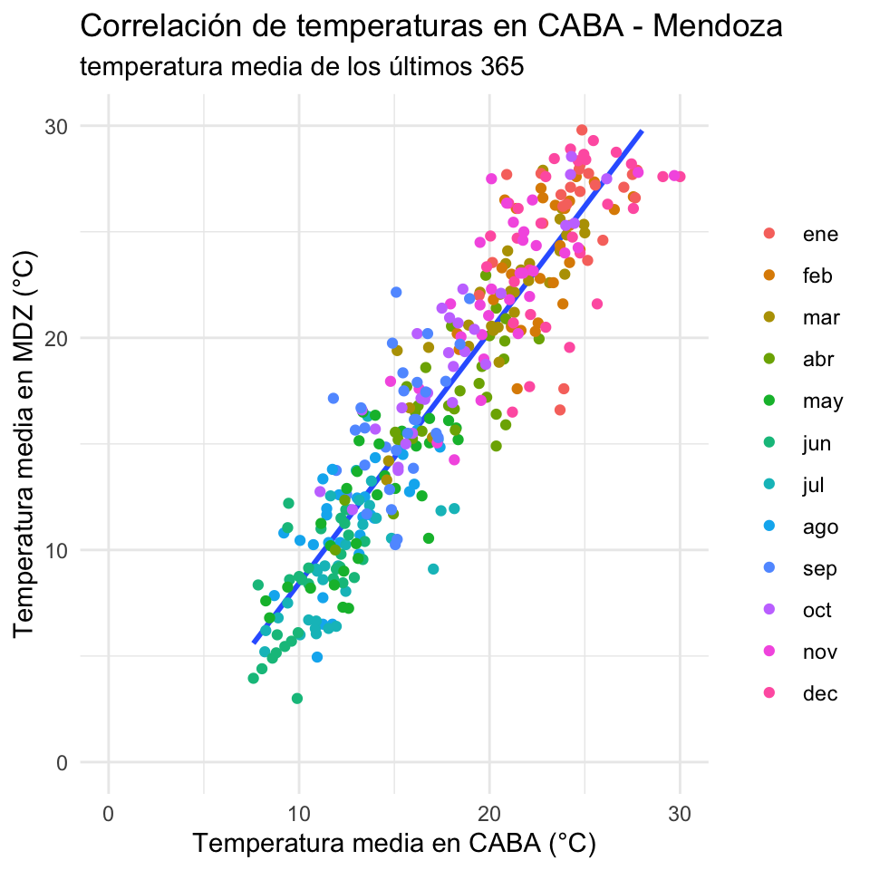

## Guardo figuras

```r
ggsave( "output/fig1.pdf", plot = g1)
ggsave( "output/fig2.pdf", plot = g2)
ggsave( "output/fig3.pdf", plot = g3)
ggsave( "output/fig4.pdf", plot = g4)
ggsave( "output/fig5.pdf", plot = g5)
```

## Referencias

- R Markdown: The Definitive Guide. Yihui Xie, J. J. Allaire, Garrett Grolemund. (https://bookdown.org/yihui/rmarkdown/)
- github.com/eclarke/ggbeeswarm
- github.com/RainCloudPlots/RainCloudPlots
- wilkelab.org/ggridges/